# Applying Empirical Risk Minimization

73-423 Forecasting for Economics and Business

## Empirical Risk Minimization

- Empirical Risk Minimizer
  $$\widehat{f}^{ERM}(\mathcal{Y}_T)=\underset{f\in\mathcal{F}}{\arg\min}\frac{1}{T-h}\sum_{t=1}^{T}\ell(y_{t+h},f(\mathcal{Y}_t))$$
- Saw in previous classes that empirical risk minimization can do a good job
  - **Most of the time**, loss is small **on average** with respect to “true” distribution, **relative** to **empirical risk** or **oracle risk**
  - If true distribution $p\in\mathcal{P}$ is **stationary** and **weak dependent** and hypothesis class $\mathcal{F}$ is **low complexity**
- Today
  - Examples of useful hypothesis classes
  - Handling (some) cases of nonstationarity, strong dependence

## Linear Function Classes

- Let $\mathcal{Z}_T=\{z_t\}_{t=1}^{T}$, $z_t\in\mathbb{R}^d$ be some set of “predictor variables”
- $z_t$ may include
  - Lagged values of series to be forecast $\{y_{t-k}\}_{k=0}^{p}$
  - A constant term $1$
  - Other variables known at time $t$
    $$\mathcal{F}(\mathbf{Z})=\{f(z)=\sum_{j=1}^dz_j\beta_j:\ \beta\in\mathbb{R}^{d}\}$$
- Most commonly used function class by far in all areas of data analysis
- ERM with linear class goes by many different names
  - Square Loss: Ordinary Least Squares Regression
  - Absolute Loss: Least Absolute Deviations Regression
  - Categorical Cross-Entropy Loss: Logistic Regression

## Predictors

- Role of predictors $z_t$ is to provide information about $y_{t+h}$
- Want $\mathcal{F}(\mathbf{Z})$ such that oracle risk $\underset{f\in\mathcal{F}(\mathbf{Z})}{\min}R_p(f)$ is small
  - Choose variables such that $\sum_{j=1}^d\beta_jz_{jt}$ provides good description of $y_{t+h}$
  - Use intuition, economic theory, and availability of measurements to find predictors
- Past values of $y_t$ (almost) always available and often closely associated
- Economically relevant variables depend on context
  - Often $y_t$ related to other variables by accounting identity, e.g. $y_t=z_{1t}+z_{2t}$ by definition
- Note that we need to predict $y_{t+h}$ using $z_t$, not $z_{t+h}$
  - Can use past but not contemporaneous values, so knowing $y_t$ depends on $z_t$ not enough
  - Can help to use multiple lags of $z_t$
- Also want class such that generalization error is small
  - Depends on sample size, model complexity, and dependence
    - If sample small or strongly dependent, use simpler class
    - All predictors need to satisfy stationarity and weak dependence: not just $y_t$
  - Best class for ERM usually **not** class minimizing oracle risk

## Nonlinear predictors

- Using a linear function class does not require linear relationship between variables
- Can include nonlinear transformations of variables $z_t$ as predictors
  $$\Phi(z_t)=\{\phi_j(z_t)\}_{j=1}^J$$
- Class becomes $\mathcal{F}(\Phi(\mathbf{Z}))=\sum_{j=1}^{J}\beta_j\phi_j(z_t)$
- Examples:
  - Polynomials: $\phi_j(z)=z^{j-1}$
  - Multivariate polynomials: $\phi_{j}(z)=z_1^{j_1}\cdot z_2^{j_2}\cdot\ldots z_d^{j_d}$
  - Piecewise polynomials (splines): $\phi_{jk}(z)=z^k1\{t_{j-1}<z<t_{j}\}$
  - Trigonometric functions (Fourier): $\phi_{j}(z)=cos(\pi jz)$
  - Etc: Anything else you can think of!
- Extremely general relationships can be modeled this way
- Model complexity can blow up if many nonlinear terms used
  - In multivariate case, # of parameters exponential in $d$
  - Run into overfitting problems very quickly: can do very badly in practice

## Linear regression

- Ordinary Least Squares (OLS) regression solves ERM for square loss and linear function class
  $$\widehat{\beta}=\underset{\beta\in\mathbb{R}^d}{\arg\min}\frac{1}{T-h}\sum_{t=1}^{T-h}(y_{t+h}-\sum_{j=1}^dz_{jt}\beta_j)^2$$
- Implementation: minimizer has known formula
  - For case where predictors are past values, have `Arima`,`arima`, `Ar` commands
  - For general predictors $z_t$, use `lm` (or `tslm` or `dynlm` when working with lags)

```r
#Select coefficients (b0,b1,b2,b3) by minimizing square loss
regression<-lm(y~z1+z2+z3)
#Produce forecasts by evaluating regression function at latest values
regressionforecast<-forecast(regression,zt)
#AR(2) forecast
autoregression<-dynlm(y~L(y,1)+L(y,2))
autoregressionforecast<-predict(autoregression,zt)
```

## Application: GDP Growth Forecasting

- The US Bureau of Economic Analysis collects aggregate economic data in the National Income and Product Accounts
- Gross Domestic Product (GDP) is measure of the market value of total output in the US economy
  - Used as a measure of aggregate economic activity in all areas
  - Forecasts used by policymakers and businesses to plan for level of expenditures
- Composed, by definition, of sum of Consumption + Investment + Government Spending + Net Exports
  - Y = C + I + G + NX
- Predict quarterly log changes using lagged change and lags of changes in components (exclude one for redundancy)
  $$\underset{\beta\in\mathbb{R}^5}{\min}\frac{1}{T-1}\sum_{t=1}^{T-1}(\Delta Y_{t+1}-(\beta_0+\beta_1\Delta Y_{t}+\beta_2\Delta C_{t}+\beta_3\Delta I_{t}+\beta_4\Delta G_{t}))^2$$

```r
##Empirical example: GDP and Recession forecasting

library(fredr) #Access FRED, the Federal Reserve Economic Data
library(fpp2) #Analysis and manipulation functions for forecasting
library(dynlm) #Linear Model for Time Series Data
library(quantreg) #quantile Regression
fredr_set_key("8782f247febb41f291821950cf9118b6") #Key I obtained for this class

#US GDP components
GDP<-fredr(series_id = "GDP",
           observation_start = as.Date("1947-01-01"),
           observation_end=as.Date("2021-02-27"),
           vintage_dates = as.Date("2021-02-27")) #Gross Domestic Product

#US GDP components from NIPA tables (cf http://www.bea.gov/national/pdf/nipaguid.pdf)
PCEC<-fredr(series_id = "PCEC",
           observation_start = as.Date("1947-01-01"),
           observation_end=as.Date("2021-02-27"),
           vintage_dates = as.Date("2021-02-27")) #Personal consumption expenditures
FPI<-fredr(series_id = "FPI",
           observation_start = as.Date("1947-01-01"),
           observation_end=as.Date("2021-02-27"),
           vintage_dates = as.Date("2021-02-27")) #Fixed Private Investment
CBI<-fredr(series_id = "CBI",
           observation_start = as.Date("1947-01-01"),
           observation_end=as.Date("2021-02-27"),
           vintage_dates = as.Date("2021-02-27")) #Change in Private Inventories
NETEXP<-fredr(series_id = "NETEXP",
           observation_start = as.Date("1947-01-01"),
           observation_end=as.Date("2021-02-27"),
           vintage_dates = as.Date("2021-02-27")) #Net Exports of Goods and Services
GCE<-fredr(series_id = "GCE",
           observation_start = as.Date("1947-01-01"),
           observation_end=as.Date("2021-02-27"),
           vintage_dates = as.Date("2021-02-27")) #Government Consumption Expenditures and Gross Investment

#Format the series as quarterly time series objects, starting at the first date
gdp<-ts(GDP$value,frequency = 4,start=c(1947,1),names="Gross Domestic Product")
pcec<-ts(PCEC$value,frequency = 4,start=c(1947,1),names="Consumption")
fpi<-ts(FPI$value,frequency = 4,start=c(1947,1),names="Fixed Investment")
cbi<-ts(CBI$value,frequency = 4,start=c(1947,1),names="Inventory Growth")
invest<-fpi+cbi #Private Investment
netexp<-ts(NETEXP$value,frequency = 4,start=c(1947,1),names="Net Exports")
gce<-ts(GCE$value,frequency = 4,start=c(1947,1),names="Government Spending")

# ## Plot Data
#
# autoplot(gdp, series="Gross Domestic Product")+
#   autolayer(pcec,series="Consumption")+
#   autolayer(invest,series="Investment")+
#   autolayer(netexp,series="Net Exports")+
#   autolayer(gce,series="Government Spending")+
#   ggtitle("US GDP and NIPA Components") +
#   ylab("Billions of Dollars")+xlab("Date")+
#   guides(colour=guide_legend(title="NIPA Component"))

## Predict using OLS on lagged predictors
#gdpdynlm<-dynlm(d(gdp)~L(d(gdp))+L(d(pcec))+L(d(invest))+L(d(gce))+L(d(netexp)))

#Restate as aligned variables of same length
dgdp<-window(diff(log(gdp)),start=c(1947,3),end=c(2020,4))
ldgdp<-window(lag(diff(log(gdp)),-1),end=c(2020,4))
ldpcec<-window(lag(diff(log(pcec)),-1),end=c(2020,4))
ldinvest<-window(lag(diff(log(invest)),-1),end=c(2020,4))
ldgce<-window(lag(diff(log(gce)),-1),end=c(2020,4))
#ldnetexp<-window(lag(diff(netexp),-1),end=c(2020,4)) #Exclude net exports, which is sometimes negative

#Predict using OLS
gdpOLS<-lm(dgdp~ldgdp+ldpcec+ldinvest+ldgce)

#Collect Q42020 Data for Q12021 Forecast
last<-length(diff(pcec)) #Index of last observation for all series, Q4 2020
zt<-data.frame(diff(log(gdp))[last],diff(log(pcec))[last],diff(log(invest))[last],diff(log(gce))[last])
colnames(zt)<-c("ldgdp","ldpcec","ldinvest","ldgce")

#Predict
gdpfcstOLS<-predict(gdpOLS,zt)
```

```r
#Use OLS to predict GDP growth from lagged component growth
gdpOLS<-lm(dgdp~ldgdp+ldpcec+ldinvest+ldgce)
#Predict value for 2021Q1, using 2020Q4 data
gdpfcstOLS<-predict(gdpOLS,zt)
```

## Loss Guarantees for OLS

- Bayes forecast for square loss is (conditional) expectation $m^*(\mathcal{Z}_T):=E_p[y_{t+h}|\mathcal{Z}_T]$
- Oracle forecast rule solves $\underset{f\in\mathcal{F}(\mathbf{Z})}{\min}E_p[(m^*(\mathcal{Z}_T)-f(\mathcal{Z}_T))^2]$
  - OLS approximates conditional mean: oracle risk smallest when $\mathcal{F}(\mathbf{Z})$ contains this
- For any $p\in\mathcal{P}$ such that $(y_{t+h},z_t)$ stationary and mixing with finite variance
  - Probability that excess risk relative to oracle exceeds any fixed constant $c$ goes to 0 as $T\to\infty$
  - p(($\frac{1}{T-h}\sum_{t=1}^{T-h}(y_{t+h}-\sum_{j=1}^dz_{jt}\widehat{\beta}^{\text{OLS}}_j)^2-\underset{f\in\mathcal{F}}{\min}E_p[(y_{t+h}-\sum_{j=1}^dz_{jt}\beta_j)^2])>c)\overset{T\to\infty}{\to}0$
- Above conditions do not say anything about finite $T$ excess risk
  - Uniform bounds require stronger conditions
  - Problem is that $\mathcal{F}$ unbounded: predictions could be anywhere
  - A claim: “Its performance is… typically poor in most applications” (Mohri et al 2018, p276)
  - Depends on the use case: often a strong performer in economic data
- Simplicity, interpretability, ease of use make it popular method

## Least Absolute Deviations regression

- LAD regression solves ERM for absolute (MAE) loss and linear function class
  $$\widehat{\beta}=\underset{\beta\in\mathbb{R}^d}{\arg\min}\frac{1}{T-h}\sum_{t=1}^{T-h}\left|y_{t+h}-\sum_{j=1}^dz_{jt}\beta_j\right|$$
- Absolute Error weights small forecast errors more and large forecast errors less than square loss
  - Predictions tolerate more large errors but do better with typical case
- Can show (won’t prove) that best predictor is the (conditional) **median** of $y$ given $z$
  - P(y<=median(y|z)|z)=P(y>=median(y|z)|z)=0.5
  - Searches for a value so you are as likely to be wrong above as below
- Implementation: minimizer computable by fast algorithm as a special case of quantile regression
  - Use `rq` command in library `quantreg`

```r
#Select coefficients (b0,b1,b2,b3,b4) by minimizing absolute loss
gdpLAD<-rq(dgdp~ldgdp+ldpcec+ldinvest+ldgce)
#Produce forecasts by evaluating regression function at latest values
gdpfcstLAD<-predict(gdpLAD,zt)
```

## Application: Comparison of LAD and OLS Forecasts

- Forecasts of log GDP growth in 2021Q1
  - OLS: 0.0165646
  - LAD: 0.0140319,

```r
library(knitr)
library(kableExtra)

#Table of results
payemerrors<-data.frame(Coefficient=c("Constant",
                  "Delta log(Y_{t-1})","Delta log(C_{t-1})","Delta log(I_{t-1})",
                  "Delta log(G_{t-1})"),
  OLScoeffs=gdpOLS$coefficients,
  LADcoeffs=gdpLAD$coefficients)
kable(payemerrors,
  col.names=c("Coefficient","OLS",
              "LAD"),
  caption="Coefficients for ERM in GDP Growth Forecast")
```

Coefficients for ERM in GDP Growth Forecast

|  | Coefficient | OLS | LAD |
| --- | --- | --- | --- |
| (Intercept) | Constant | 0.0116165 | 0.0079664 |
| ldgdp | Delta log(Y_{t-1}) | -0.6160785 | -0.2348550 |
| ldpcec | Delta log(C_{t-1}) | 0.5118518 | 0.5045953 |
| ldinvest | Delta log(I_{t-1}) | 0.1389572 | 0.0713135 |
| ldgce | Delta log(G_{t-1}) | 0.1860983 | 0.0860652 |

- Predictions are fairly similar, but not the same
  - Weight different events differently
  - Bigger differences can occur if median far from mean

## Log GDP Growth and OLS vs LAD Predictions

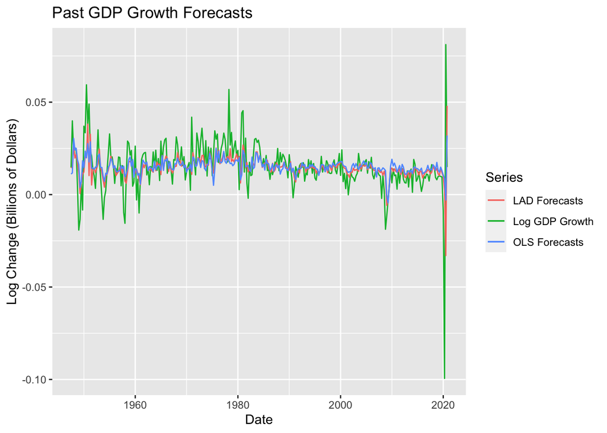

```r
#Contemporaneous Predictions
LADfcsts<-ts(predict(gdpLAD),frequency=4,start=c(1947,3))
OLSfcsts<-ts(predict(gdpOLS),frequency=4,start=c(1947,3))

autoplot(dgdp,series="Log GDP Growth")+
  autolayer(LADfcsts,series="LAD Forecasts")+
  autolayer(OLSfcsts,series="OLS Forecasts")+
  ggtitle("Past GDP Growth Forecasts") +
   ylab("Log Change (Billions of Dollars)")+xlab("Date")+
   guides(colour=guide_legend(title="Series"))
```

## Exercise

- Try out OLS and LAD regression yourself with a Kaggle notebook on [Covid and Economic Activity](https://www.kaggle.com/davidchilders/covid-and-economic-activity)

## Binary Prediction

- $y_t$ a binary (0,1) variable: 1 if something happened, 0 if it didn’t
  - Recession or no recession, default or no default, buy or don’t buy
- Could use loss function which is small if prediction right, large if wrong
  - 0-1 Loss: $0$ if $\widehat{y}_t=y_t$, $1$ if $\widehat{y}_t\neq y_t$
  - Useful if forecast must be a **classifier**: make binary decision based on outcome
- Alternately: allow forecasts $\widehat{y}\in[0,1]$ and use loss based on closeness to $y$
  - Useful if goal is to learn probability of outcome
- **Categorical cross-entropy loss** $\ell(y,\widehat{y})=y\log(\widehat{y})+(1-y)\log(1-\widehat{y})$
  - 0 if $\widehat{y}=y$, $\infty$ if $\widehat{y}=1-y$
  - $E_p[\ell(y,\widehat{y})]$ minimized at $\widehat{y}=p(y=1)$
- **Brier score** is name given to square loss for binary prediction
  - $E_p[(y-\widehat{y})^2]$ also minimized at $\widehat{y}=p(y=1)$
- Can turn $\widehat{y}\in[0,1]$ to classifier $\in\{0,1\}$ by thresholding
  - Predict $1\{\widehat{y}>c\}$, usually for $c=0.5$

## Logistic Regression

- To make prediction in $[0,1]$, apply monotone transformation $F:\ \mathbb{R}\to[0,1]$ to linear predictor class
  - Typical choice: **Logistic** (or **softmax**) function $F(x)=\frac{\exp(x)}{1+\exp(x)}$
  - Apply ERM to loss $y\log(F(f))+(1-y)\log(1-F(f))$
- **Logistic regression** solves ERM for cross-entropy loss and softmax applied to linear function class
  $$\widehat{\beta}=\underset{\beta\in\mathbb{R}^d}{\arg\min}\frac{1}{T-h}\sum_{t=1}^{T-h}(y_{t+h}\log(F(\sum_{j=1}^dz_{jt}\beta_j))+(1-y_{t+h})\log(1-F(\sum_{j=1}^dz_{jt}\beta_j)))$$
- Implementation: minimizer computable by fast algorithm
  - Use `glm` command with option `family=binomial(link="logit")`

```r
#Select coefficients (b0,b1,b2,b3) by minimizing categorical cross-entropy loss
logitregression<-glm(y~z1+z2+z3,family=binomial(link="logit"))
#Produce forecasts by evaluating regression function at latest values
logitregressionforecast<-predict(logitregression,zt,type="response")
```

## Application: Recession Forecasting

- A recession is a period of sustained economic contraction
  - Characterized informally as “a sequence of two or more quarters of negative output growth”
- Official dates are declared by the National Bureau of Economic Research (NBER) Business Cycle Dating Committee
  - Monthly $(0,1)$ variable going back to 1854
- Use logistic regression with 2 lags of past indicator as predictors

```r
#The NBER recession indicator has FRED ID "USREC"
#1 in NBER declared recession, 0 in any other date
USREC<-fredr(series_id = "USREC",
           vintage_dates = as.Date("2021-02-27"))
usrec<-ts(USREC$value,frequency=12,start=c(1854,12)) #Convert to time series
#Produce lagged values
l1usrec<-window(lag(usrec,-1),start=c(1855,2),end=c(2021,1))
l2usrec<-window(lag(usrec,-2),start=c(1855,2),end=c(2021,1))
recession<-window(usrec,start=c(1855,2),end=c(2021,1))
```

```r
recessionlogit<-glm(recession~l1usrec+l2usrec,family=binomial(link="logit"))
```

```r
recessionlogit$coefficients
```

```
## (Intercept)     l1usrec     l2usrec
##   -3.672571   20.854996  -14.427029
```

- Coefficients go into softmax function to produce a probability of recession
  - Being in a recession this month predicts higher chance next month
  - But being in a recession two months ago predicts lower chance

## Recessions, Predicted and Observed

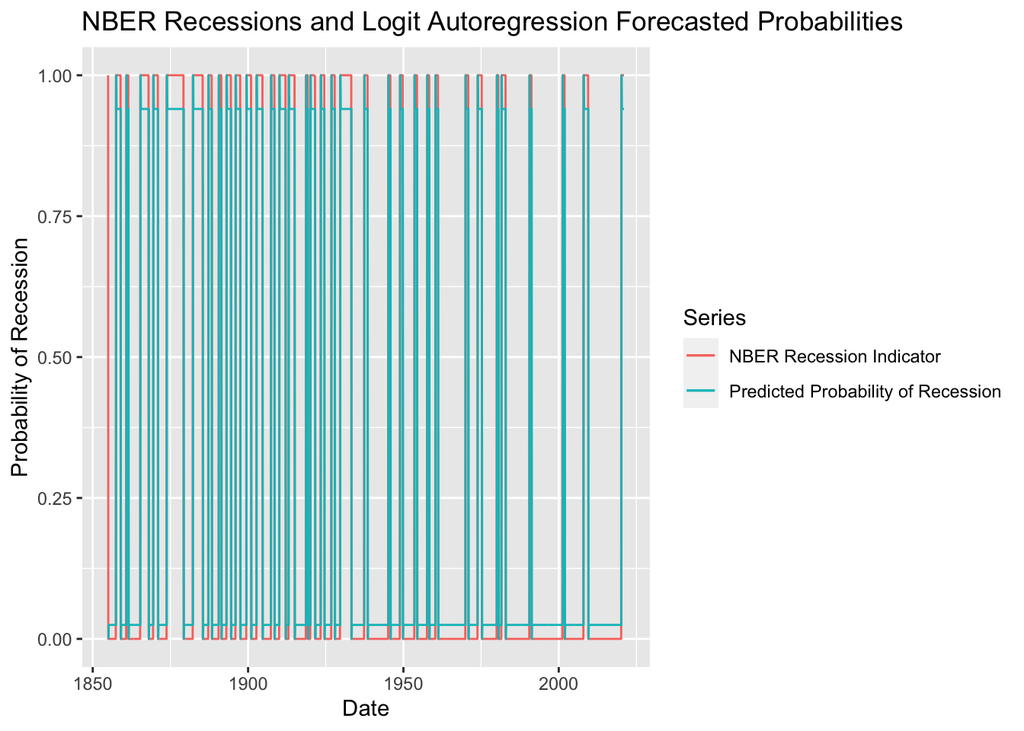

```r
probs<-predict(recessionlogit,type="response")
recessionprobs<-ts(probs,frequency=12,start=c(1855,2))
autoplot(usrec,series="NBER Recession Indicator")+
  autolayer(recessionprobs,series="Predicted Probability of Recession")+
  ggtitle("NBER Recessions and Logit Autoregression Forecasted Probabilities") +
   ylab("Probability of Recession")+xlab("Date")+
   guides(colour=guide_legend(title="Series"))
```

## What if my data isn’t stationary or weak dependent?

- Principle of ERM relies on assumptions
  - Future data will be like past data
  - Sample averages are good approximation of future averages
- There are infinite ways this can be violated
  - Nothing says that data that looks “well behaved” now will continue to be so in the future
  - If this is a major concern, there is little the statistical approach can offer
  - Online learning approach (much later) can help, but only by changing objective
- Often, we face slightly simpler problems
  - Stationarity or weak dependence fail, but in detectable and correctable ways
  - At least for these, important to check and perform the needed corrections

## Nonstationary probability models

- A probability model $p$ is nonstationary if $p(y_{t})\neq p(y_{s})$
  - Distribution $p_t(y_t)$ depends on time $t$
- Goal becomes to find rule $f_{t}$ to achieve small **time-dependent risk**
  $$R_{p_{T+h}}(f):=E_{p_{T+h}}\ell(y_{T+h},f_{T}(\mathcal{Y}_T))$$
- One model of nonstationarity: **additive components model**
  - $y_t=\tilde{y}_t+T(t)$, $\tilde{y}_t\sim\tilde{p}(.)$ stationary and weak dependent, $T(t)$ a deterministic function of time
- If $\log(y_t)$ is additive components model, call it multiplicative components model
- Examples
  - Linear Trend: $T(t)=ct$ for a constant $c$
  - Deterministic Seasonality: $T(t)=\sum_{j=1}^{k}a_j1\{t\mod k=j\}$ (eg, add $a_j$ in month $j$)
  - Structural breaks: $T(t)=c\cdot 1\{T\geq k\}$ for constant c, break date $k$
  - Outliers: $T(t)=c1\{T=k\}$ add c at date $k$
  - Smooth Trend: $T(t)$ is an arbitrary “smooth” (eg 2x differentiable) function

## Restoring stationarity

- If way that distribution depends on time is **known**, can use this to make predictions
- One possible solution: find invertible transform $\tilde{\mathcal{Y}}_t=T(\mathcal{Y}_t,t)$ so that $\tilde{\mathcal{Y}}_t$ is stationary
- In additive components model, just subtract nonstationary part $T(t)$
  - $\tilde{y}_t=y_t-T(t)$ is stationary and weak dependent
- Goes by different names depending on form of nonstationarity
  - Detrending, deseasonalizing, break removal
- Other models may require other transformations
- Differencing: $\Delta y_t=y_{t}-y_{t-1}$
  - Turns linear trends into constant $\Delta(ct)=c$, random walk $y_{t}=y_{t-1}+e_{t}$ into $e_t$, stationary series
- Double (triple, etc) differencing $\Delta^{k}y_t=\Delta\Delta\ldots\Delta{y}_t$
  - Removes linear and quadratic (cubic, etc) trends
  - If difference of series is a random walk, double difference is stationary
- Seasonal differencing: $y_{t}-y_{t-k}$
  - Removes additive seasonality at frequency $k$

## Applying ERM with detrending

- Detrended ERM Procedure
  1. Detrend data $\tilde{\mathcal{Y}}_T=\{\tilde{y}_t\}_{t=1}^{T}$
  2. Apply ERM to detrended data $\widehat{f}^{ERM}(\tilde{\mathcal{Y}}_T)=\underset{f\in\mathcal{F}}{\arg\min}\frac{1}{T-h}\sum_{t=1}^{T}\ell(\tilde{y}_{t+h},f(\tilde{\mathcal{Y}}_t))$
  3. Add trend back to make prediction $\widehat{y}_{T+h}=\widehat{f}^{ERM}(\tilde{\mathcal{Y}}_T)+T(T+h)$
- Suppose loss function depends only on distance $\ell(x,y)=\ell(x-y,0)$
  - True for square loss, absolute loss, etc
- Then $E_{p_{T+h}}\ell(y_{T+h},\widehat{y}_{T+h})$ $=E_{p}\ell(y_{T+h}-T(T+h),\widehat{f}^{ERM}(\tilde{\mathcal{Y}}_T))$ $=E_{p}\ell(\tilde{y}_{T+h},\widehat{f}^{ERM}(\tilde{\mathcal{Y}}_T))$
- Result: risk guarantees for $y_t$ are same as those for $\tilde{y}_t$, which satisfies usual ERM conditions

## What if source of nonstationarity not known?

- In some cases, theory or prior knowledge tells you about trend
  - Stock variables likely to contain linear trends or random walk behavior
  - Efficient Market Hypothesis: Prices in financial markets are random walks
  - Solution: forecast differences instead of levels!
  - Add differences back to get levels if needed
- In other cases, some parameters $\theta$ of trend $T(t,\theta)$ not known
  - Slope $c$ of linear trend $ct$, size $a_j$ of month/quarter seasonal effects,etc
- Posssible solution: estimate $T(t,\theta)$ by procedure $T(.,\widehat{\theta})$ using data
- Method 1: detrend then apply ERM
  1. Estimate trend $\widehat{\theta}=\underset{\theta}{\arg\min}\frac{1}{T}\sum_{t=1}^{T}\ell(y_t,T(t,\theta))$
  2. Run ERM on approximate detrended data $\widehat{f}^{ERM}(\tilde{\mathcal{Y}}_T)=\underset{f\in\mathcal{F}}{\arg\min}\frac{1}{T-h}\sum_{t=1}^{T}\ell(y_{t+h}-T(.,\widehat{\theta}),f(\mathcal{Y}_t-T(.,\widehat{\theta})))$
- Method 2: Apply ERM including trend
  1. $(\widehat{f}^{ERM}(\tilde{\mathcal{Y}}_T),\widehat{\theta})=\underset{(f\in\mathcal{F},\theta)}{\arg\min}\frac{1}{T-h}\sum_{t=1}^{T}\ell(y_{t+h},f(\mathcal{Y}_t)+T(.,\theta))$

## Implementation

- Joint procedure extremely easy to implement for linear model class
  - Just add $T(.,\theta)$ to regression equation
- Commands `dynlm`, `tslm` can include linear trend, seasonality, etc in ordinary least squares formula

```r
#OLS with prediction rule b_0+b1*z1_t+b2*y_{t-1}+c*t+sum(a_j*season_j)
regression<-dynlm(y~z1+L(y)+trend(y)+season(y))
```

- Or just create variables and include in prediction equation

## When does this method work?

- For ERM under usual conditions, do **not** have to assume that model $\mathcal{F}$ is “correct”
  - Here “correct” means $\mathcal{F}$ contains the Bayes forecast rule
  - Still approach best risk in class $\mathcal{F}$
- In nonstationary case **do** need transformation $T(t)$ to be the correct one
  - If $T(t)$ known exactly $\tilde{y}_t=y_t-T(t)$ is stationary
  - If $\widehat{T}(t)$ is approximated, $\widehat{\tilde{y}}_t=y_t-\widehat{T}(t)$ is not stationary
- ERM applied with approximate detrending does not have same guarantees
  - Most straightforward problem: error from $\widehat{T}(T+h)-T(t+h)$ added
  - Harder problem: if stationarity not exact, chosen $f$ may be affected
- Hard to show general results, but in many cases, additional approximation error is small
  - Linear (or polynomial) trends and seasonality known to have small effect on error of OLS
  - Bonus slides give some sufficient conditions on $\ell$, $\mathcal{F}$, $\widehat{T}(.)$ for small error
- In other cases additional approximation error known to be a big problem
  - Especially for smooth trends (cf Hamilton 2018)

## Conclusions

- ERM with linear hypotheses provides simple and interpretable forecasting tool
  - Can accomodate past values, external predictors, and nonlinearities
- Performance usually okay with larger samples
  - If data stationary and model not too complicated
- Transforming, deseasonalizing, detrending, etc can be used to get back to stationarity
- If nonstationaity takes additive form, this can be added as variable in linear predictor

## References

- James Hamilton “Why You Should Never Use the Hodrick-Prescott Filter” *Review of Economics and Statistics* 100 (December 2018): 831-843.
  - Explains some serious problems that can arise for forecasting when using a smoothing spline to approximate a smooth trend (A process called “the Hodrick-Prescott Filter” by economists)

## Bonus Slide: Risk From Approximate Detrending

- Consider additive components model $y_t=\tilde{y}_t+T(t)$
- Assume $\widehat{T}(.)$ converges to $T(t)$ with high probability in $p$
  - w.p. $1-\delta$, $\underset{t\in1\ldots T+h}{\max}\left|\widehat{T}(t)-T(t)\right|\leq b(\delta,T)\overset{T\to\infty}{\to}0$
  - Use some method to get uniformly accurate trend estimates
- Let $\ell(y,\widehat{y})=\ell(y-\widehat{y},0)$ be $L_1$-Lipschitz
  - $\left|\ell(x+a,0)-\ell(x,0)\right|\leq L_1\left|a\right|$ for all $x,a$
  - Permits absolute loss but not square loss
- Let all $f\in\mathcal{F}$ be $L_2$ Lipschitz in all $d$ arguments
  - Permits linear predictors if coefficients bounded
- Want to bound excess risk of post-detrending predictor relative to oracle with known $T(t)$ and distribution $p$

$$\underset{f\in\mathcal{F}}{\min}\frac{1}{T-h}\sum_{t=1}^{T-h}\ell(y_{t+h},f(\{y_s-\widehat{T}(s)\}_{s=1}^{t})+\widehat{T}(t+h))-\underset{f\in\mathcal{F}}{\min}E_{p}[\ell(y_{T+h},f(\{y_s-T(s)\}_{s=1}^{T})+T(T+h))]$$

## Bonus Slide 2: Proof of Bound

- Consider approximate detrended empirical risk minus exactly detrended empirical risk
  $$\underset{f\in\mathcal{F}}{\min}\frac{1}{T-h}\sum_{t=1}^{T-h}\ell(y_{t+h},f(\{y_s-\widehat{T}(s)\}_{s=1}^{t})+\widehat{T}(t+h))-\underset{f\in\mathcal{F}}{\min}\frac{1}{T-h}\sum_{t=1}^{T-h}\ell(y_{t+h},f(\{y_s-T(s)\}_{s=1}^{t})+T(t+h))$$
- Difference in min bounded by max of difference
  $$\leq \underset{f\in\mathcal{F},t\in1\ldots T}{\sup}\left|\ell(y_{t+h},f(\{y_s-\widehat{T}(s)\}_{s=1}^{t})+\widehat{T}(t+h)-\ell(y_{t+h},f(\{y_s-T(s)\}_{s=1}^{t})-T(t+h)\right|$$
- By Lipschitz conditions bound by $\leq (dL_1L_2+1)\underset{t\in1\ldots T+h}{\max}\left|\widehat{T}(t)-T(t)\right|$
- Add and subtract exactly detrended empirical risk to bound excess risk by $(dL_1L_2+1)\underset{t\in1\ldots T+h}{\max}\left|\widehat{T}(t)-T(t)\right|+$
  $$(\underset{f\in\mathcal{F}}{\min}\frac{1}{T-h}\sum_{t=1}^{T-h}\ell(y_{t+h},f(\{y_s-T(s)\}_{s=1}^{t})+T(t+h))-\underset{f\in\mathcal{F}}{\min}E_{p}[\ell(y_{T+h},f(\{y_s-T(s)\}_{s=1}^{T})+T(T+h))])$$
- Last term is excess risk of ERM for exactly detrended data
  - Bounded with high probability by standard ERM inequality under usual assumptions
- First term bounded with high probability by (uniform) consistency of detrending method